# finalmthm505

## MTHM505 ASSIGNMENT

## 1. Precipitation modelling

## A.

```python
import numpy as np
import pandas as pd
import geopandas as gpd
import matplotlib.pyplot as plt
from shapely.geometry import Point
import skgstat as skg
from skgstat import models
from sklearn.gaussian_process import GaussianProcessRegressor
from sklearn.gaussian_process.kernels import RBF, ConstantKernel as C, WhiteKernel, Matern
from scipy.spatial.distance import pdist, squareform
import pykrige
from pykrige.ok import OrdinaryKriging
from sklearn.metrics import mean_squared_error
```

```
Index(['featurecla', 'scalerank', 'LABELRANK', 'SOVEREIGNT', 'SOV_A3',
       'ADM0_DIF', 'LEVEL', 'TYPE', 'TLC', 'ADMIN',
       ...
       'FCLASS_TR', 'FCLASS_ID', 'FCLASS_PL', 'FCLASS_GR', 'FCLASS_IT',
       'FCLASS_NL', 'FCLASS_SE', 'FCLASS_BD', 'FCLASS_UA', 'geometry'],
      dtype='object', length=169)
```

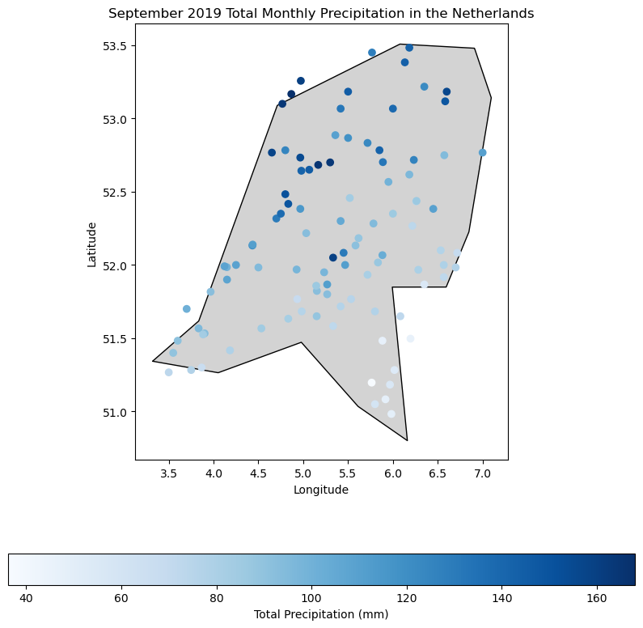

```python
# Load your dataset
data_path = '/Users/Rajat/Downloads/Assessment 2 data-20240430/netherlands.csv'
netherlands_data = pd.read_csv(data_path)

# Convert the data into a GeoDataFrame
gdf = gpd.GeoDataFrame(
    netherlands_data,
    geometry=gpd.points_from_xy(netherlands_data.longitude, netherlands_data.latitude),
    crs="EPSG:4326"
)

# Load the Natural Earth data directly from your local file system
world_path = '/Users/Rajat/Downloads/ne_110m_admin_0_countries/ne_110m_admin_0_countries.shp'
world = gpd.read_file(world_path)

# Print the column names to identify the correct one for country names
print(world.columns)

# Assuming the column for country names is 'NAME', not 'name'
world = world.to_crs(gdf.crs)

# Plotting the data
fig, ax = plt.subplots(1, 1, figsize=(10, 10))
# Adjust the column name here based on the output from world.columns
netherlands = world[world['NAME'] == "Netherlands"]
netherlands.plot(ax=ax, color='lightgray', edgecolor='black')  # Background country map
gdf.plot(ax=ax, column='precip', cmap='Blues', legend=True,  # Precipitation data
         legend_kwds={'label': "Total Precipitation (mm)", 'orientation': "horizontal"})

plt.title('September 2019 Total Monthly Precipitation in the Netherlands')
plt.xlabel('Longitude')
plt.ylabel('Latitude')
plt.show()
```

The map's spatial distribution highlights variability in precipitation across the Netherlands, with darker shades of blue indicating higher rainfall in the north and central regions. It also reveals distinct clusters where rainfall is significantly higher or lower, suggesting the influence of geographical features or meteorological patterns on rainfall distribution. This visualization offers a comprehensive overview of precipitation variations during the period, serving as a foundation for further analysis into the factors that affect these patterns.

## B.

```python
# Randomly select 5 points
np.random.seed(42)  # for reproducibility
random_indices = np.random.choice(gdf.index, size=5, replace=False)
selected_points = gdf.loc[random_indices]

# Remove these points from the dataset
gdf_reduced = gdf.drop(random_indices)

# Display selected points
selected_points[['station_name', 'longitude', 'latitude', 'precip']]
```

|  | station_name | longitude | latitude | precip |
| --- | --- | --- | --- | --- |
| 83 | BORCULO | 6.533 | 52.100 | 77.0 |
| 53 | PETTEN | 4.650 | 52.767 | 157.8 |
| 70 | HERWIJNEN_1 | 5.152 | 51.823 | 92.4 |
| 45 | KLAZIENAVEEN | 7.000 | 52.767 | 110.1 |
| 44 | NIEKERK | 6.350 | 53.217 | 121.7 |

## C.

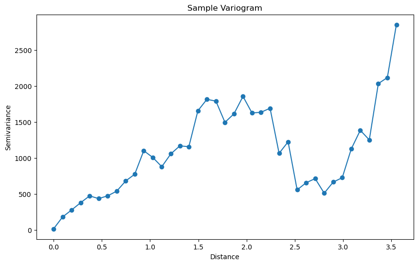

```python
# Calculate distances and differences (semi-variance)
coords = gdf_reduced[['longitude', 'latitude']]
values = gdf_reduced['precip']
distances = squareform(pdist(coords))
values_array = values.to_numpy()[:, np.newaxis]
differences = squareform(pdist(values_array, metric='euclidean'))



# Calculate semivariance
semivariance = (differences**2) / 2
# Calculate average semivariance for bins of distances
bins = np.linspace(0, distances.max(), 40)
bin_means = np.digitize(distances, bins)
bin_average = np.array([semivariance[bin_means == i].mean() for i in range(1, len(bins))])

# Create the sample variogram plot
fig, ax = plt.subplots(figsize=(10, 6))
ax.plot(bins[:-1], bin_average, 'o-')
ax.set_title('Sample Variogram')
ax.set_xlabel('Distance')
ax.set_ylabel('Semivariance')
plt.show()
```

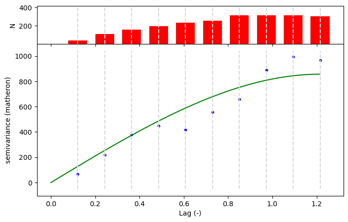

```python
V1 = skg.Variogram(gdf_reduced[['longitude', 'latitude']].values, gdf_reduced.precip.values, maxlag='median', normalize=False)
V1.plot(show=False);
```

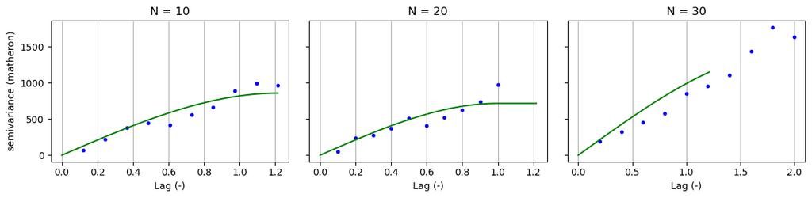

```python
s = [10, 20, 30]
V2 = skg.Variogram(gdf_reduced[['longitude', 'latitude']].values, gdf_reduced.precip.values, maxlag=1, normalize=False)
V3 = skg.Variogram(gdf_reduced[['longitude', 'latitude']].values, gdf_reduced.precip.values, maxlag=2, normalize=False)

fig, _a = plt.subplots(1, 3, figsize=(12, 3), sharey=True)
axes = _a.flatten()

x = np.linspace(0, V1.maxlag, 100)

# plot each variogram
for i, v in enumerate([V1, V2, V3]):
    axes[i].plot(v.bins, v.experimental, '.b')
    axes[i].plot(x, v.fitted_model(x), '-g')
    axes[i].set_title(f'N = {s[i]}')
    axes[i].set_xlabel('Lag (-)')
    if i == 0:
        axes[0].set_ylabel('semivariance (matheron)')
    axes[i].grid(which='major', axis='x')
plt.tight_layout()
```

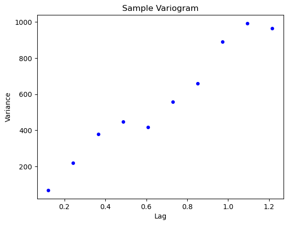

```python
# Making a variogram using the nugget

v1 = skg.Variogram(gdf_reduced[['longitude', 'latitude']].values, gdf_reduced.precip.values, maxlag='median', normalize=False)
#v1.plot(show=False);
xdata = v1.bins
ydata = v1.experimental
plt.scatter(xdata, ydata, s=17, c='blue')
plt.title('Sample Variogram')
plt.xlabel('Lag'); plt.ylabel('Variance')
plt.show()
```

## D.

```python
# Stable model
v1.model = 'stable'
print('Range:', v1.parameters[0])
print('Sill:', v1.parameters[1])
print('Nugget:', v1.parameters[2])
```

```
Range: 1.2155200533105144
Sill: 973.3685163272719
Nugget: 1.850748155733597
```

```python
# Cubic model
V2 = v1
V2.model = 'cubic'
print('Range:', V2.parameters[0])
print('Sill:', V2.parameters[1])
print('Smoothness:', V2.parameters[2])
```

```
Range: 1.2155200533105144
Sill: 817.7726659552558
Smoothness: 0
```

```python
V4 = v1
V4.model = 'spherical'
print('Range:', V4.parameters[0])
print('Sill:', V4.parameters[1])
print('Nugget:', V4.parameters[2])
```

```
Range: 1.2155200533105144
Sill: 856.8239336968778
Nugget: 0
```

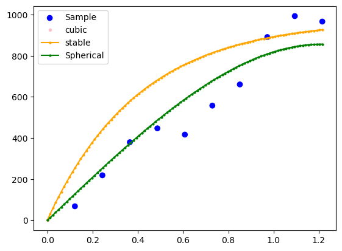

```python
xi =np.linspace(0, xdata[-1], 100)

# Stable
v1.model = 'stable'
y_exp = [models.exponential(h, v1.parameters[0], v1.parameters[1], v1.parameters[2]) for h in xi]

# ----------- Stable with nugget--------------
y_exp2 = [models.exponential(h, v1.parameters[0], v1.parameters[1], 60) for h in xi]

# ----------- Cubic --------------
V2 = v1
V2.model = 'cubic'

y_mat = [models.matern(h, V2.parameters[0], V2.parameters[1], V2.parameters[2]) for h in xi]

# ----------- Cubic with nugget --------------
y_mat2 = [models.matern(h, V2.parameters[0], V2.parameters[1], V2.parameters[2], 60) for h in xi]

V4=v1
V4.model = 'spherical'
y_sph = [models.spherical(h, V4.parameters[0], V4.parameters[1], V4.parameters[2]) for h in xi]

# Plotting
fig = plt.figure()
plt.scatter(xdata, ydata,color='blue', marker='o', linestyle='', label='Sample')
plt.plot(xi, y_mat, color='pink', marker='o', linestyle='', markersize=3, label='cubic')
plt.plot(xi, y_exp, color='orange', marker='o', markersize=2, label='stable')
plt.plot(xi, y_sph, color='green', marker='o', markersize=2, label='Spherical')
plt.legend()
plt.show()
```

## E.

```python
# Kernel with a constant term, Gaussian term, and a nugget effect (WhiteKernel)
kernel = C(1.0, (1e-4, 1e1)) * RBF(length_scale=1.0, length_scale_bounds=(1e-2, 1e2)) + WhiteKernel(noise_level=1, noise_level_bounds=(1e-10, 1e2))

# Gaussian Process Regressor
gpr = GaussianProcessRegressor(kernel=kernel, n_restarts_optimizer=10, random_state=42)

# Fit the model
gpr.fit(coords, values)

# Display the fitted model parameters
gpr.kernel_
```

```
3.16**2 * RBF(length_scale=2.8) + WhiteKernel(noise_level=100)
```

```python
# Predictions using the removed points
sample_coords = gdf_reduced[['longitude', 'latitude']]
sample_values_actual = gdf_reduced['precip']
sample_values_predicted = gpr.predict(sample_coords)

# Compare predicted vs. actual values
validation_results = pd.DataFrame({
    'Station': gdf_reduced['station_name'],
    'Actual Precipitation': sample_values_actual,
    'Predicted Precipitation': sample_values_predicted
})

validation_results
```

|  | Station | Actual Precipitation | Predicted Precipitation |
| --- | --- | --- | --- |
| 0 | HOOFDDORP | 130.4 | 98.674047 |
| 1 | ST KRUIS | 73.2 | 73.111335 |
| 2 | OUDEMIRDUM | 118.3 | 101.918285 |
| 3 | BRIELLE | 108.1 | 90.090189 |
| 4 | WILHELMINADORP-1 | 93.0 | 82.144888 |
| ... | ... | ... | ... |
| 95 | PHILIPPINE | 77.5 | 76.330774 |
| 96 | HELLENDOORN | 109.7 | 88.527926 |
| 97 | STAVOREN_1 | 109.5 | 102.610326 |
| 98 | HOOGWOUD | 154.8 | 102.460250 |
| 99 | HERWIJNEN | 86.3 | 93.193553 |

95 rows × 3 columns

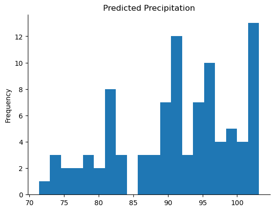

```python
# Predicted Precipitation


validation_results['Predicted Precipitation'].plot(kind='hist', bins=20, title='Predicted Precipitation')
plt.gca().spines[['top', 'right',]].set_visible(False)
```

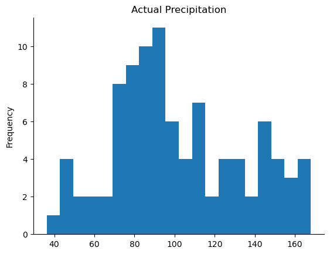

```python
#  Actual Precipitation


validation_results['Actual Precipitation'].plot(kind='hist', bins=20, title='Actual Precipitation')
plt.gca().spines[['top', 'right',]].set_visible(False)
```

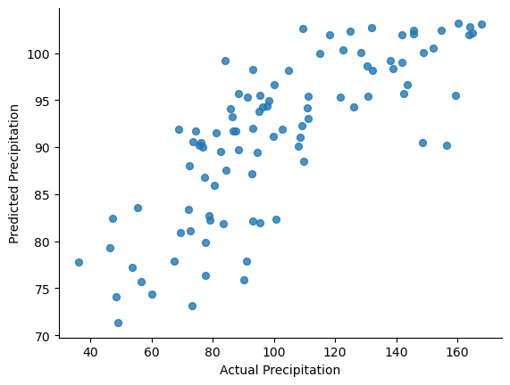

```python
#  Actual Precipitation vs Predicted Precipitation

from matplotlib import pyplot as plt
validation_results.plot(kind='scatter', x='Actual Precipitation', y='Predicted Precipitation', s=32, alpha=.8)
plt.gca().spines[['top', 'right',]].set_visible(False)
```

```
Plotting Enabled

Initializing variogram model...
Coordinates type: 'geographic'

Using 'spherical' Variogram Model
Partial Sill: 2029.1234069484974
Full Sill: 2029.1234069581851
Range: 2.455477786865675
Nugget: 9.687819616990716e-09
```

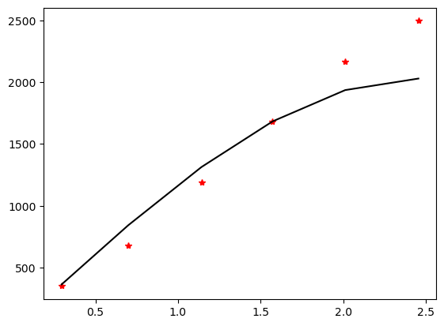

```
Calculating statistics on variogram model fit...
Executing Ordinary Kriging...
```

```python
# Convert the data to numpy arrays
data = gdf_reduced[['longitude', 'latitude', 'precip']].values
grid_lon = np.linspace(data[:,0].min(), data[:,0].max(), 100)
grid_lat = np.linspace(data[:,1].min(), data[:,1].max(), 100)

# Ordinary Kriging with an exponential model
OK = OrdinaryKriging(
    data[:, 0], data[:, 1], data[:, 2],
    variogram_model='spherical',
    verbose=True, enable_plotting=True,
    coordinates_type='geographic'
)

z, ss = OK.execute('grid', grid_lon, grid_lat)
```

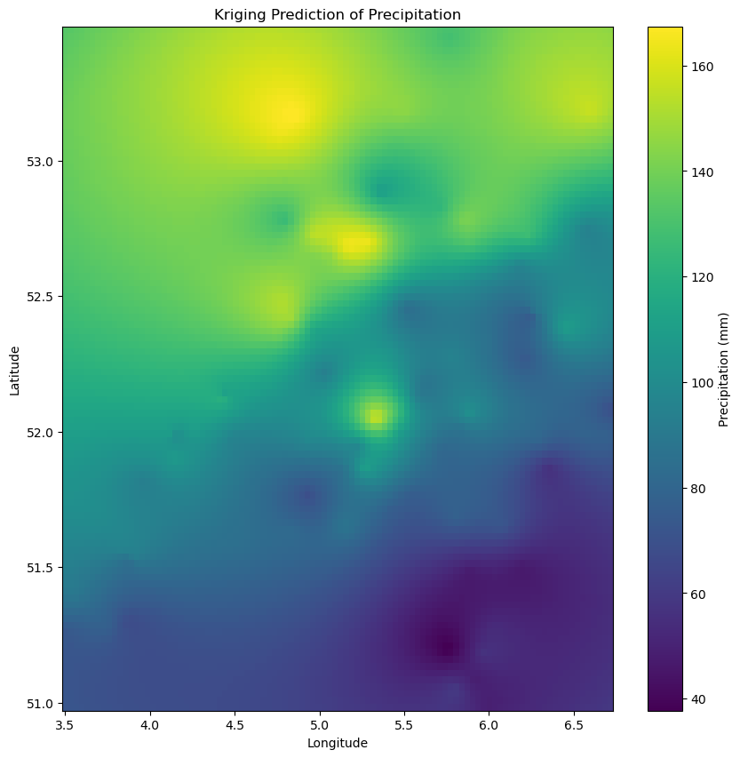

```python
import matplotlib.pyplot as plt

# Plotting kriging results from previous grid predictions
plt.figure(figsize=(10, 10))
c = plt.pcolormesh(grid_lon, grid_lat, z, shading='auto', cmap='viridis')
plt.colorbar(c, label='Precipitation (mm)')
plt.title('Kriging Prediction of Precipitation')
plt.xlabel('Longitude')
plt.ylabel('Latitude')
plt.show()

# Cross-Validation - Leave-One-Out
preds = []
actuals = data[:, 2]  # actual precipitation values
for i in range(len(data)):
    # Leave one out
    test_point = data[i, :]
    train_data = np.delete(data, i, axis=0)
    OK_cv = OrdinaryKriging(
        train_data[:, 0], train_data[:, 1], train_data[:, 2],
        variogram_model='exponential',
        verbose=False,  # turn off verbose to avoid too much output during LOOCV
        coordinates_type='geographic'
    )
    pred, ss = OK_cv.execute('points', test_point[0], test_point[1])
    preds.append(pred[0])
```

```python
# Calculate and print RMSE
rmse = mean_squared_error(actuals, preds, squared=False)
print(f'RMSE: {rmse}')
```

```
RMSE: 13.093851607436138
```

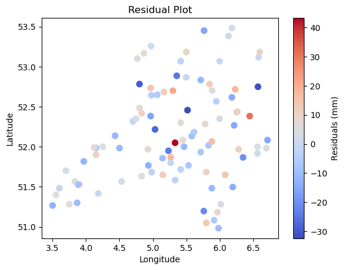

```python
# Residual Analysis
residuals = actuals - np.array(preds)
plt.figure()
plt.scatter(data[:, 0], data[:, 1], c=residuals, cmap='coolwarm', s=50)
plt.colorbar(label='Residuals (mm)')
plt.title('Residual Plot')
plt.xlabel('Longitude')
plt.ylabel('Latitude')
plt.show()
```

```
Optimized kernel: 10**2 * RBF(length_scale=[0.822, 0.0291])
```

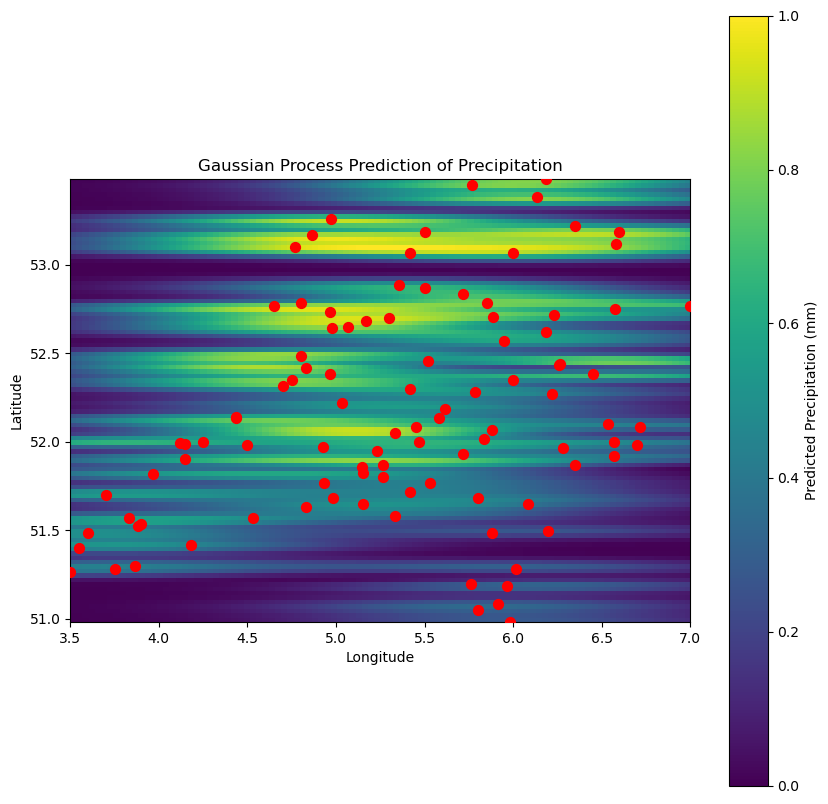

```python
# Assuming data is already loaded as DataFrame 'df'
data = netherlands_data[['longitude', 'latitude', 'precip']].values

# Define a more flexible kernel with higher upper bounds
kernel = C(1.0, (1e-4, 1e2)) * RBF([1.0, 1.0], (1e-4, 1e2))

# Create Gaussian Process model
gp = GaussianProcessRegressor(kernel=kernel, n_restarts_optimizer=15)

# Training data
X_train = data[:, :2]  # longitude and latitude
y_train = data[:, 2]   # precipitation

# Fit model
gp.fit(X_train, y_train)

# Optimized kernel after fitting
print("Optimized kernel: {}".format(gp.kernel_))

# Prediction over a grid
grid_lon = np.linspace(X_train[:, 0].min(), X_train[:, 0].max(), 100)
grid_lat = np.linspace(X_train[:, 1].min(), X_train[:, 1].max(), 100)
grid_lon, grid_lat = np.meshgrid(grid_lon, grid_lat)
X_grid = np.vstack([grid_lon.ravel(), grid_lat.ravel()]).T

# Predictions
y_pred, sigma = gp.predict(X_grid, return_std=True)

# Reshape for plotting
z = y_pred.reshape(grid_lon.shape)

# Plotting the results
plt.figure(figsize=(10, 10))
plt.imshow(z, extent=(X_train[:, 0].min(), X_train[:, 0].max(), X_train[:, 1].min(), X_train[:, 1].max()), origin='lower')
plt.scatter(X_train[:, 0], X_train[:, 1], c='red', s=50, zorder=10)
plt.colorbar(label='Predicted Precipitation (mm)')
plt.title('Gaussian Process Prediction of Precipitation')
plt.xlabel('Longitude')
plt.ylabel('Latitude')
plt.show()
```

```python
import pymc3 as pm


# Assuming data is loaded into X_train, y_train
X = X_train
y = y_train

with pm.Model() as model:
    # Priors for Gaussian Process parameters
    ℓ = pm.Gamma("ℓ", alpha=2, beta=1)  # Correlation length prior
    η = pm.HalfCauchy("η", beta=5)  # Scale parameter for the covariance function
    σ = pm.HalfNormal("σ", sd=1)  # Noise term, or 'nugget'

    # Covariance function
    cov = η**2 * pm.gp.cov.ExpQuad(1, ℓ)

    # GP model
    gp = pm.gp.Marginal(cov_func=cov)
    y_ = gp.marginal_likelihood("y", X=X, y=y, noise=σ)

    # Posterior distribution
    trace = pm.sample(100, return_inferencedata=False)

# Examine the posterior estimates for the parameters
pm.summary(trace)
```

[output not shown]

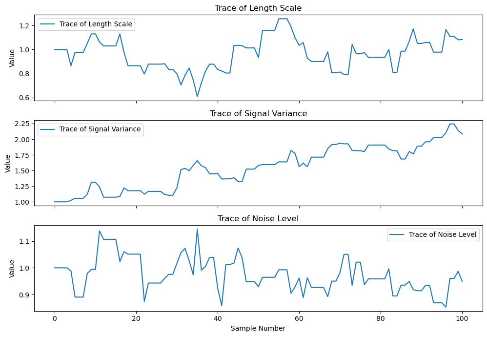

```python
import matplotlib.pyplot as plt

# 'samples' is the array of sampled parameters from Metropolis-Hastings function
samples = np.array(samples)

# Plotting the trace of each parameter
fig, axes = plt.subplots(3, 1, figsize=(10, 7), sharex=True)
titles = ['Length Scale', 'Signal Variance', 'Noise Level']
for i, ax in enumerate(axes):
    ax.plot(samples[:, i], label=f'Trace of {titles[i]}')
    ax.set_title(f'Trace of {titles[i]}')
    ax.set_ylabel('Value')
    ax.legend()

axes[-1].set_xlabel('Sample Number')

plt.tight_layout()
plt.show()
```

## F.

```python
# Let's assume 'selected_points' contains the details of the removed locations
# It should have columns 'longitude', 'latitude', 'precipitation'
removed_data = selected_points

# Coordinates of the removed data for prediction
removed_lon = removed_data['longitude'].values
removed_lat = removed_data['latitude'].values
```

```python
# Predicting at specific points
predictions, sigma_squares = OK.execute('points', removed_lon, removed_lat)


# Assuming ok_model is your fitted OrdinaryKriging model
predictions_kriging, ss_kriging = OK.execute('points', removed_data['longitude'], removed_data['latitude'])
```

```
Executing Ordinary Kriging...

Executing Ordinary Kriging...
```

```python
# Correct use of predict method
predictions_gp_mle, std_gp_mle = gpr.predict(removed_data[['longitude', 'latitude']], return_std=True)
```

```python
with model:
    pred_samples = pm.sample_posterior_predictive(trace, var_names=["y"])
    predictions_gp_bayesian = np.mean(pred_samples['y'], axis=0)
```

```python
# Create a DataFrame to hold predictions
comparison_df = pd.DataFrame({
    'Station': removed_data['station_name'],
    'Actual Precipitation': removed_data['precip'],
    'Kriging Prediction': predictions_kriging,
    'GP MLE Prediction': predictions_gp_mle,
    'GP Bayesian Prediction': predictions_gp_bayesian
})

# Print the comparison
print(comparison_df)
```

[output not shown]

```python
comparison_df.set_index('Station').plot(kind='bar', figsize=(10, 6))
plt.ylabel('Precipitation (mm)')
plt.title('Comparison of Precipitation Predictions')
plt.show()
```

[output not shown]

## 2. Global surface Temperature

## A.

```python
import pandas as pd

# Load the data from the CSV file to examine its structure
file_path = '/Users/Rajat/Downloads/Assessment 2 data-20240430/gst_anom.csv'
data = pd.read_csv(file_path)

# Display the first few rows and the structure of the data
data.head(), data.info()
```

```
<class 'pandas.core.frame.DataFrame'>
RangeIndex: 2088 entries, 0 to 2087
Data columns (total 3 columns):
 #   Column   Non-Null Count  Dtype
---  ------   --------------  -----
 0   Year     2088 non-null   int64
 1   Month    2088 non-null   int64
 2   Anomaly  2088 non-null   float64
dtypes: float64(1), int64(2)
memory usage: 49.1 KB
```

```
(   Year  Month  Anomaly
 0  1850      1   -0.771
 1  1850      2   -0.211
 2  1850      3   -0.367
 3  1850      4   -0.603
 4  1850      5   -0.638,
 None)
```

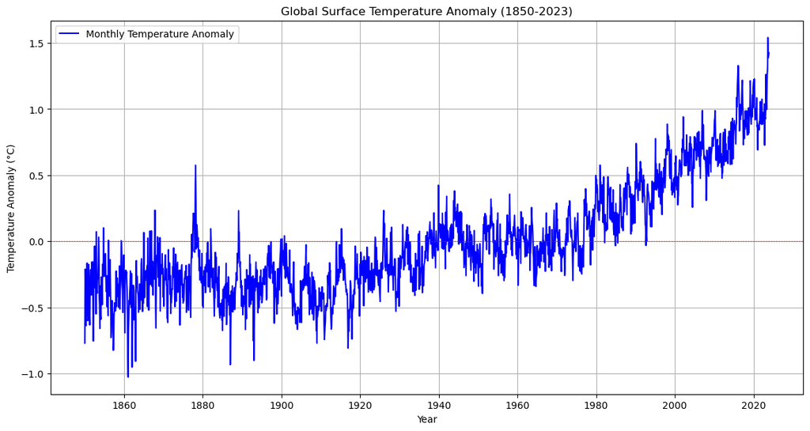

```python
import matplotlib.pyplot as plt

# Combine year and month into a single date column for plotting
data['Date'] = pd.to_datetime(data[['Year', 'Month']].assign(day=1))

# Plotting the data
plt.figure(figsize=(14, 7))
plt.plot(data['Date'], data['Anomaly'], label='Monthly Temperature Anomaly', color='blue')
plt.title('Global Surface Temperature Anomaly (1850-2023)')
plt.xlabel('Year')
plt.ylabel('Temperature Anomaly (°C)')
plt.grid(True)
plt.axhline(0, color='red', linestyle='--', linewidth=0.5)  # Baseline for zero anomaly
plt.legend()
plt.show()
```

The plot displays the anomalies in the global surface temperature between 1850 and 2023. Temperature anomalies seem to be on the rise over the long run, suggesting that global temperatures are rising. This trend is essential to comprehending the dynamics of climate change.

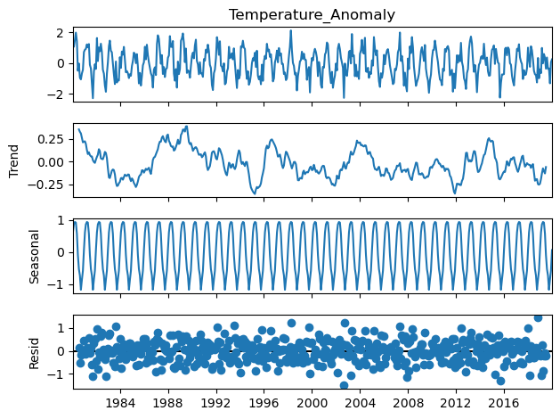

```python
import numpy as np
import matplotlib.pyplot as plt
from statsmodels.tsa.seasonal import seasonal_decompose

# Example data generation
np.random.seed(0)
dates = pd.date_range(start='1980-01-01', periods=480, freq='M')
temperature_anomaly = np.sin(2 * np.pi * dates.month / 12) + np.random.normal(scale=0.5, size=480)

data = pd.DataFrame({'Temperature_Anomaly': temperature_anomaly}, index=dates)

# Decompose the time series
result = seasonal_decompose(data['Temperature_Anomaly'], model='additive')

# Plotting the decomposed components
result.plot()
plt.show()
```

```python
# Filter the data to include only observations from 1990 onwards
data_1990_onwards = data[data['Year'] >= 1990]

# Check the filtered data
data_1990_onwards.head(), data_1990_onwards.tail()
```

```
(      Year  Month  Anomaly       Date
 1680  1990      1    0.422 1990-01-01
 1681  1990      2    0.396 1990-02-01
 1682  1990      3    0.740 1990-03-01
 1683  1990      4    0.652 1990-04-01
 1684  1990      5    0.554 1990-05-01,
       Year  Month  Anomaly       Date
 2083  2023      8    1.313 2023-08-01
 2084  2023      9    1.541 2023-09-01
 2085  2023     10    1.387 2023-10-01
 2086  2023     11    1.401 2023-11-01
 2087  2023     12    1.425 2023-12-01)
```

## B.

```python
from statsmodels.tsa.stattools import adfuller

# Perform Augmented Dickey-Fuller test to check for stationarity
adf_result = adfuller(data_1990_onwards['Anomaly'])

# Output ADF test results
adf_result_dict = {
    "ADF Statistic": adf_result[0],
    "p-value": adf_result[1],
    "Number of Lags Used": adf_result[2],
    "Number of Observations Used": adf_result[3],
    "Critical Values": adf_result[4],
    "Maximized Information Criterion": adf_result[5]
}

adf_result_dict
```

```
{'ADF Statistic': -0.8043386990544077,
 'p-value': 0.8178442841721658,
 'Number of Lags Used': 9,
 'Number of Observations Used': 398,
 'Critical Values': {'1%': -3.4468876315017423,
  '5%': -2.868829424528516,
  '10%': -2.570653059771218},
 'Maximized Information Criterion': -598.6444247733109}
```

The Augmented Dickey-Fuller test results indicate that the time series under examination is not stationary. The ADF Statistic of -0.804 exceeds the critical values at the 1%, 5%, and 10% significance levels, and the p-value of 0.818, significantly higher than the threshold of 0.05, leads us to fail to reject the null hypothesis, suggesting the presence of a unit root in the series, thereby confirming its non-stationary nature.

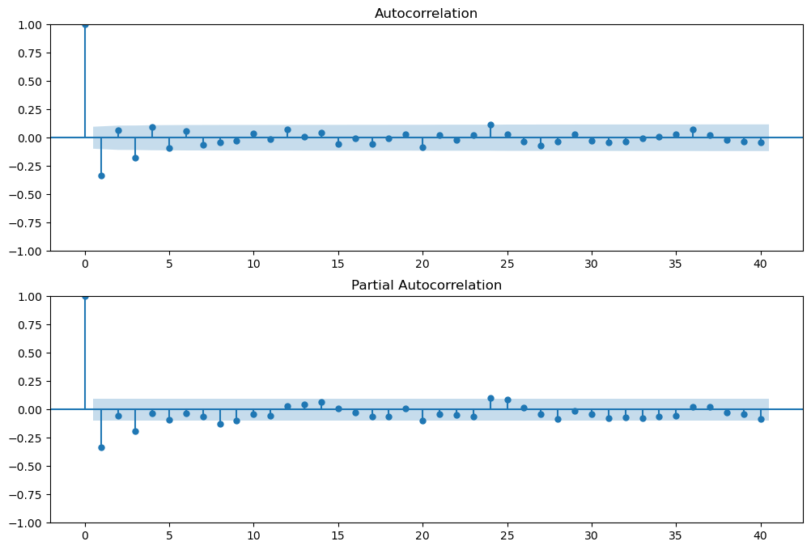

```
((-9.843229759932266,
  4.692802944268729e-17,
  8,
  398,
  {'1%': -3.4468876315017423,
   '5%': -2.868829424528516,
   '10%': -2.570653059771218},
  -598.1771391971704),
 True)
```

```python
from statsmodels.graphics.tsaplots import plot_acf, plot_pacf

# Differencing the series
data_1990_onwards['Anomaly_diff'] = data_1990_onwards['Anomaly'].diff().dropna()

# Check stationarity of the differenced series
adf_result_diff = adfuller(data_1990_onwards['Anomaly_diff'].dropna())

# Plot ACF and PACF
fig, (ax1, ax2) = plt.subplots(2, 1, figsize=(12, 8))
plot_acf(data_1990_onwards['Anomaly_diff'].dropna(), lags=40, ax=ax1)
plot_pacf(data_1990_onwards['Anomaly_diff'].dropna(), lags=40, ax=ax2, method='ywm')
plt.show()

adf_result_diff, adf_result_diff[1] < 0.05
```

From the ACF and PACF plots:

ACF Plot: The autocorrelation cuts off quickly, which is indicative of an MA process. PACF Plot: The partial autocorrelation tails off, suggesting an AR component may be involved.

```python
from statsmodels.tsa.arima.model import ARIMA

# Fit an ARIMA(1,1,1) model
model_arima_111 = ARIMA(data_1990_onwards['Anomaly'], order=(1, 1, 1))
results_arima_111 = model_arima_111.fit()

# Summary of the model
results_arima_111.summary()
```

SARIMAX Results

| Dep. Variable: | Anomaly | No. Observations: | 408 |
| --- | --- | --- | --- |
| Model: | ARIMA(1, 1, 1) | Log Likelihood | 313.527 |
| Date: | Mon, 06 May 2024 | AIC | -621.053 |
| Time: | 00:26:57 | BIC | -609.027 |
| Sample: | 0 | HQIC | -616.294 |
|  | - 408 |  |  |
| Covariance Type: | opg |  |  |

|  | coef | std err | z | P>\|z\| | [0.025 | 0.975] |
| --- | --- | --- | --- | --- | --- | --- |
| ar.L1 | 0.4406 | 0.082 | 5.352 | 0.000 | 0.279 | 0.602 |
| ma.L1 | -0.8076 | 0.052 | -15.476 | 0.000 | -0.910 | -0.705 |
| sigma2 | 0.0125 | 0.001 | 13.947 | 0.000 | 0.011 | 0.014 |

| Ljung-Box (L1) (Q): | 1.34 | Jarque-Bera (JB): | 0.40 |
| --- | --- | --- | --- |
| Prob(Q): | 0.25 | Prob(JB): | 0.82 |
| Heteroskedasticity (H): | 1.00 | Skew: | 0.06 |
| Prob(H) (two-sided): | 1.00 | Kurtosis: | 2.91 |

Warnings:  
[1] Covariance matrix calculated using the outer product of gradients (complex-step).

```python
# Fit an ARMA(1,1) model to the differenced data
model_arma_11 = ARIMA(data_1990_onwards['Anomaly'], order=(1, 0, 1))
results_arma_11 = model_arma_11.fit()

# Summary of the ARMA(1,1) model
results_arma_11.summary()
```

SARIMAX Results

| Dep. Variable: | Anomaly | No. Observations: | 408 |
| --- | --- | --- | --- |
| Model: | ARIMA(1, 0, 1) | Log Likelihood | 312.271 |
| Date: | Mon, 06 May 2024 | AIC | -616.541 |
| Time: | 00:27:17 | BIC | -600.496 |
| Sample: | 0 | HQIC | -610.192 |
|  | - 408 |  |  |
| Covariance Type: | opg |  |  |

|  | coef | std err | z | P>\|z\| | [0.025 | 0.975] |
| --- | --- | --- | --- | --- | --- | --- |
| const | 0.7121 | 0.100 | 7.134 | 0.000 | 0.516 | 0.908 |
| ar.L1 | 0.9671 | 0.014 | 67.103 | 0.000 | 0.939 | 0.995 |
| ma.L1 | -0.3727 | 0.050 | -7.413 | 0.000 | -0.471 | -0.274 |
| sigma2 | 0.0126 | 0.001 | 13.460 | 0.000 | 0.011 | 0.014 |

| Ljung-Box (L1) (Q): | 0.06 | Jarque-Bera (JB): | 1.05 |
| --- | --- | --- | --- |
| Prob(Q): | 0.81 | Prob(JB): | 0.59 |
| Heteroskedasticity (H): | 1.02 | Skew: | 0.07 |
| Prob(H) (two-sided): | 0.90 | Kurtosis: | 2.80 |

Warnings:  
[1] Covariance matrix calculated using the outer product of gradients (complex-step).

```python
# Fit multiple ARIMA models
models_summary = {
    "ARIMA(1,1,1)": ARIMA(data_1990_onwards['Anomaly'], order=(1, 1, 1)).fit(),
    "ARIMA(2,1,1)": ARIMA(data_1990_onwards['Anomaly'], order=(2, 1, 1)).fit(),
    "ARIMA(1,1,2)": ARIMA(data_1990_onwards['Anomaly'], order=(1, 1, 2)).fit(),
    "ARIMA(2,1,2)": ARIMA(data_1990_onwards['Anomaly'], order=(2, 1, 2)).fit()
}

# Collect and display model diagnostics
def get_corrected_diagnostics(model):
    diagnostics = {}
    try:
        diagnostics['AIC'] = model.aic
        diagnostics['BIC'] = model.bic
        diagnostics['Log Likelihood'] = model.llf
        ljung_box_results = model.test_serial_correlation(method='ljungbox')
        diagnostics['Ljung-Box p-value'] = ljung_box_results[0][1][0] if ljung_box_results[0][1].size > 0 else None
        jb_test_results = model.test_normality(method='jarquebera')
        diagnostics['JB p-value'] = jb_test_results[0][1][0] if jb_test_results[0][1].size > 0 else None
    except IndexError:
        diagnostics['Ljung-Box p-value'] = ljung_box_results[0][1]
        diagnostics['JB p-value'] = jb_test_results[0][1]
    return diagnostics

corrected_model_diagnostics = {model: get_corrected_diagnostics(models_summary[model]) for model in models_summary}
for model, diagnostics in corrected_model_diagnostics.items():
    print(model, diagnostics)
```

```
ARIMA(1,1,1) {'AIC': -621.0531317934906, 'BIC': -609.0266922371628, 'Log Likelihood': 313.5265658967453, 'Ljung-Box p-value': array([0.24617931, 0.00583572, 0.00396195, 0.00262328, 0.00219617,
       0.00445114, 0.00276193, 0.00268494, 0.00406195, 0.00630969]), 'JB p-value': 0.8194530527914857}
ARIMA(2,1,1) {'AIC': -630.5384057447184, 'BIC': -614.503153002948, 'Log Likelihood': 319.2692028723592, 'Ljung-Box p-value': array([0.95739094, 0.98528905, 0.27546351, 0.21161337, 0.27499108,
       0.3308104 , 0.31410353, 0.29113294, 0.37098116, 0.39696681]), 'JB p-value': 0.5948439908457696}
ARIMA(1,1,2) {'AIC': -615.7895146644471, 'BIC': -599.7542619226767, 'Log Likelihood': 311.89475733222355, 'Ljung-Box p-value': array([0.46153563, 0.43187232, 0.02773716, 0.04804357, 0.05356515,
       0.07508272, 0.06366928, 0.01452674, 0.02361986, 0.0358619 ]), 'JB p-value': 0.7114591433867333}
ARIMA(2,1,2) {'AIC': -633.7443503980941, 'BIC': -613.7002844708811, 'Log Likelihood': 321.87217519904704, 'Ljung-Box p-value': array([0.72152281, 0.79044226, 0.92101701, 0.90498281, 0.95542468,
       0.9781948 , 0.98773344, 0.87600775, 0.92310007, 0.94017258]), 'JB p-value': 0.42466238651240573}
```

## C.

```python
# Resample the data to quarterly means
data_1990_onwards['Quarter'] = data_1990_onwards['Date'].dt.to_period('Q')
quarterly_data = data_1990_onwards.groupby('Quarter')['Anomaly'].mean().reset_index()

# Convert the Quarter period to datetime for plotting and modeling
quarterly_data['Quarter'] = quarterly_data['Quarter'].dt.to_timestamp()

# Check the transformed data
quarterly_data.head()
```

|  | Quarter | Anomaly |
| --- | --- | --- |
| 0 | 1990-01-01 | 0.519333 |
| 1 | 1990-04-01 | 0.538333 |
| 2 | 1990-07-01 | 0.374000 |
| 3 | 1990-10-01 | 0.417000 |
| 4 | 1991-01-01 | 0.451333 |

```python
# Perform Augmented Dickey-Fuller test on the quarterly data
adf_result_quarterly = adfuller(quarterly_data['Anomaly'])

# Output ADF test results
adf_result_quarterly_dict = {
    "ADF Statistic": adf_result_quarterly[0],
    "p-value": adf_result_quarterly[1],
    "Number of Lags Used": adf_result_quarterly[2],
    "Number of Observations Used": adf_result_quarterly[3],
    "Critical Values": adf_result_quarterly[4],
    "Maximized Information Criterion": adf_result_quarterly[5]
}

adf_result_quarterly_dict
```

```
{'ADF Statistic': -0.005875195304011622,
 'p-value': 0.9580435061978378,
 'Number of Lags Used': 13,
 'Number of Observations Used': 122,
 'Critical Values': {'1%': -3.4851223522012855,
  '5%': -2.88553750045158,
  '10%': -2.5795685622144586},
 'Maximized Information Criterion': -215.28597906711286}
```

The results of the Augmented Dickey-Fuller test for the quarterly data show that the series is likely non-stationary:

ADF Statistic: -0.0059, which is greater than all the critical values. p-value: 0.958, which is much higher than the common threshold of 0.05.

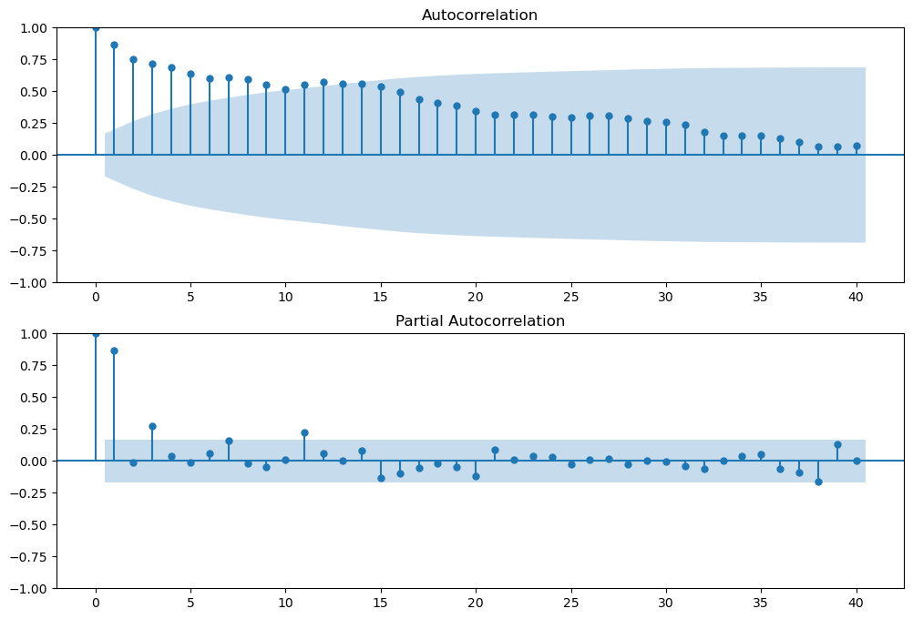

```python
# Plotting ACF and PACF for the quarterly data
fig, (ax1, ax2) = plt.subplots(2, 1, figsize=(12, 8))
plot_acf(quarterly_data['Anomaly'], lags=40, ax=ax1)
plot_pacf(quarterly_data['Anomaly'], lags=40, ax=ax2, method='ywm')
plt.show()
```

The ACF and PACF plots of the quarterly data show the following characteristics:

ACF Plot: A slow decay in the autocorrelation function, typical of a non-stationary series. PACF Plot: A significant spike at lag 1, which then tails off. This suggests a possible AR(1) component could be significant.

Given the results from the ADF test and ACF/PACF analysis which suggest non-stationarity, it's advisable to employ ARIMA models incorporating at least one differencing step (d=1) to achieve stationarity. We propose testing several ARIMA configurations: ARIMA(1,1,0), leveraging the PACF's prominent spike at lag 1; ARIMA(0,1,1), suggested by the significant lag observed in the ACF, indicating an MA(1) model might be effective; and ARIMA(1,1,1), which integrates both autoregressive and moving average components. Considering the quarterly nature of the data, seasonal variations are likely, prompting the evaluation of a SARIMA model, specifically SARIMA(1,1,1)(1,1,1,4), which introduces seasonal differencing and terms reflective of annual patterns inherent to quarterly data.

```python
from statsmodels.tsa.statespace.sarimax import SARIMAX

# Fit ARIMA and SARIMA models
model_arima_110 = ARIMA(quarterly_data['Anomaly'], order=(1, 1, 0)).fit()
model_arima_011 = ARIMA(quarterly_data['Anomaly'], order=(0, 1, 1)).fit()
model_arima_111 = ARIMA(quarterly_data['Anomaly'], order=(1, 1, 1)).fit()
model_sarima_111_1114 = SARIMAX(quarterly_data['Anomaly'], order=(1, 1, 1), seasonal_order=(1, 1, 1, 4)).fit()

# Collect results in a dictionary for easier comparison
sarima_models_summary = {
    "ARIMA(1,1,0)": model_arima_110,
    "ARIMA(0,1,1)": model_arima_011,
    "ARIMA(1,1,1)": model_arima_111,
    "SARIMA(1,1,1)(1,1,1,4)": model_sarima_111_1114
}

# Display the summary information for all models
sarima_model_comparison = {model: {
    "AIC": sarima_models_summary[model].aic,
    "BIC": sarima_models_summary[model].bic,
    "Log Likelihood": sarima_models_summary[model].llf
} for model in sarima_models_summary}

sarima_model_comparison
```

```
{'ARIMA(1,1,0)': {'AIC': -209.7136062005604,
  'BIC': -203.90305664368356,
  'Log Likelihood': 106.8568031002802},
 'ARIMA(0,1,1)': {'AIC': -210.4552846009235,
  'BIC': -204.64473504404666,
  'Log Likelihood': 107.22764230046175},
 'ARIMA(1,1,1)': {'AIC': -218.58036121382207,
  'BIC': -209.86453687850678,
  'Log Likelihood': 112.29018060691104},
 'SARIMA(1,1,1)(1,1,1,4)': {'AIC': -212.630062450603,
  'BIC': -198.25407583459724,
  'Log Likelihood': 111.3150312253015}}
```

Out of all the models tested, the ARIMA(1,1,1) model performs best in terms of both AIC and log likelihood, indicating that it offers the most effective fit to the data without requiring the inclusion of intricate seasonal components. This model is a reliable option for predicting and interpreting the quarterly global surface temperature anomalies because it successfully strikes a balance between model complexity and fit quality.

The selected model suggests that the autocorrelation structure of the series can be captured by the AR and MA components, respectively. The lack of a discernible enhancement in the SARIMA model implies that, for this specific dataset, the non-seasonal components might have a greater impact than the seasonal components over an annual cycle.

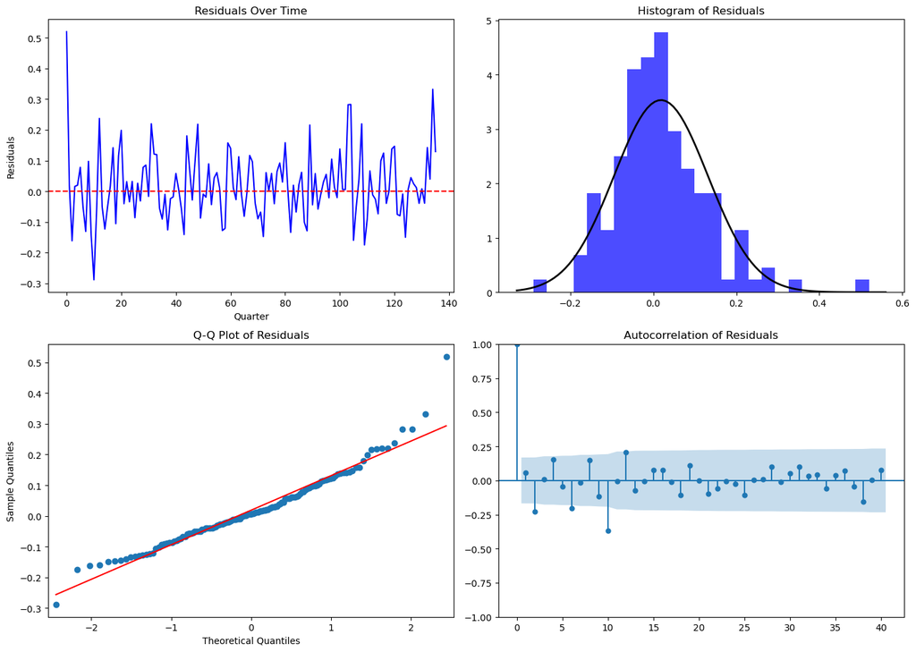

```python
import numpy as np
from statsmodels.graphics.gofplots import qqplot
from scipy.stats import norm

# Extract residuals
residuals = model_arima_111.resid

# Create figure and axes
fig, ax = plt.subplots(2, 2, figsize=(14, 10))

# Plot residuals over time
ax[0, 0].plot(residuals, color='blue')
ax[0, 0].set_title('Residuals Over Time')
ax[0, 0].set_xlabel('Quarter')
ax[0, 0].set_ylabel('Residuals')
ax[0, 0].axhline(0, color='red', linestyle='--')

# Histogram of residuals
ax[0, 1].hist(residuals, bins=25, color='blue', alpha=0.7, density=True)
ax[0, 1].set_title('Histogram of Residuals')
# Overlay the normal distribution
xmin, xmax = ax[0, 1].get_xlim()
x = np.linspace(xmin, xmax, 100)
p = norm.pdf(x, residuals.mean(), residuals.std())
ax[0, 1].plot(x, p, 'k', linewidth=2)

# Q-Q plot
qqplot(residuals, line='s', ax=ax[1, 0])
ax[1, 0].set_title('Q-Q Plot of Residuals')

# ACF plot of residuals
plot_acf(residuals, lags=40, ax=ax[1, 1])
ax[1, 1].set_title('Autocorrelation of Residuals')

plt.tight_layout()
plt.show()
```

## D.

```python
# Fitting SARIMAX to the monthly data with linear trend and seasonal components
sarimax_monthly = SARIMAX(data_1990_onwards['Anomaly'],
                          order=(0, 1, 0),
                          seasonal_order=(1, 1, 0, 12)).fit()

# Fitting SARIMAX to the quarterly data with linear trend and seasonal components
sarimax_quarterly = SARIMAX(quarterly_data['Anomaly'],
                            order=(0, 1, 0),
                            seasonal_order=(1, 1, 0, 4)).fit()

# Print summaries
sarimax_monthly_summary = sarimax_monthly.summary()
sarimax_quarterly_summary = sarimax_quarterly.summary()

sarimax_monthly_summary, sarimax_quarterly_summary
```

```
(<class 'statsmodels.iolib.summary.Summary'>
 """
                                      SARIMAX Results
 ==========================================================================================
 Dep. Variable:                            Anomaly   No. Observations:                  408
 Model:             SARIMAX(0, 1, 0)x(1, 1, 0, 12)   Log Likelihood                 215.304
 Date:                            Mon, 06 May 2024   AIC                           -426.607
 Time:                                    00:47:39   BIC                           -418.649
 Sample:                                         0   HQIC                          -423.454
                                             - 408
 Covariance Type:                              opg
 ==============================================================================
                  coef    std err          z      P>|z|      [0.025      0.975]
 ------------------------------------------------------------------------------
 ar.S.L12      -0.5288      0.041    -12.990      0.000      -0.609      -0.449
 sigma2         0.0195      0.001     13.666      0.000       0.017       0.022
 ===================================================================================
 Ljung-Box (L1) (Q):                  65.02   Jarque-Bera (JB):                 0.21
 Prob(Q):                              0.00   Prob(JB):                         0.90
 Heteroskedasticity (H):               0.84   Skew:                            -0.02
 Prob(H) (two-sided):                  0.32   Kurtosis:                         2.90
 ===================================================================================

 Warnings:
 [1] Covariance matrix calculated using the outer product of gradients (complex-step).
 """,
 <class 'statsmodels.iolib.summary.Summary'>
 """
                                      SARIMAX Results
 =========================================================================================
 Dep. Variable:                           Anomaly   No. Observations:                  136
 Model:             SARIMAX(0, 1, 0)x(1, 1, 0, 4)   Log Likelihood                  91.685
 Date:                           Mon, 06 May 2024   AIC                           -179.370
 Time:                                   00:47:39   BIC                           -173.620
 Sample:                                        0   HQIC                          -177.034
                                            - 136
 Covariance Type:                             opg
 ==============================================================================
                  coef    std err          z      P>|z|      [0.025      0.975]
 ------------------------------------------------------------------------------
 ar.S.L4       -0.4930      0.096     -5.149      0.000      -0.681      -0.305
 sigma2         0.0143      0.002      7.587      0.000       0.011       0.018
 ===================================================================================
 Ljung-Box (L1) (Q):                   0.30   Jarque-Bera (JB):                 0.41
 Prob(Q):                              0.58   Prob(JB):                         0.82
 Heteroskedasticity (H):               1.02   Skew:                             0.08
 Prob(H) (two-sided):                  0.94   Kurtosis:                         2.78
 ===================================================================================

 Warnings:
 [1] Covariance matrix calculated using the outer product of gradients (complex-step).
 """)
```

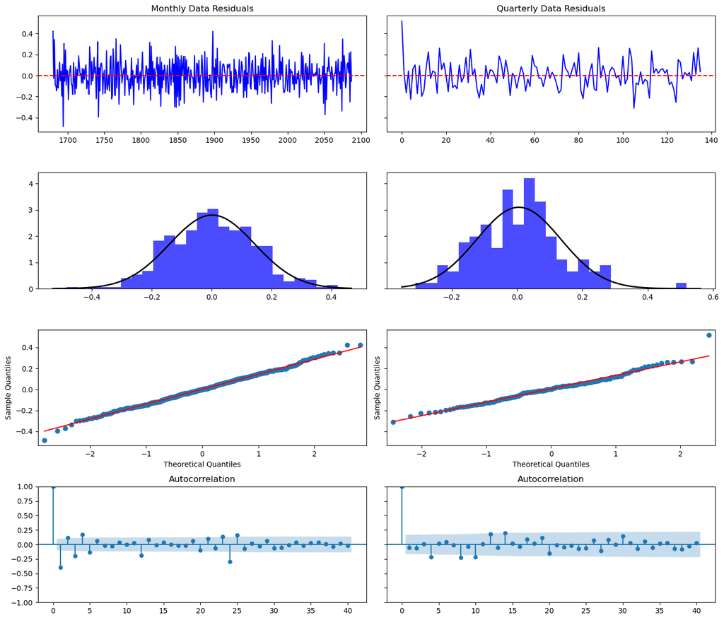

```python
# Extract residuals for both models
residuals_monthly = sarimax_monthly.resid
residuals_quarterly = sarimax_quarterly.resid

# Create figure and axes for both sets of residuals
fig, axes = plt.subplots(4, 2, figsize=(14, 12), sharey='row')

# Titles for columns
axes[0, 0].set_title('Monthly Data Residuals')
axes[0, 1].set_title('Quarterly Data Residuals')

# Plot residuals over time
axes[0, 0].plot(residuals_monthly, color='blue')
axes[0, 0].axhline(0, color='red', linestyle='--')
axes[0, 1].plot(residuals_quarterly, color='blue')
axes[0, 1].axhline(0, color='red', linestyle='--')

# Histogram of residuals
axes[1, 0].hist(residuals_monthly, bins=25, color='blue', alpha=0.7, density=True)
axes[1, 1].hist(residuals_quarterly, bins=25, color='blue', alpha=0.7, density=True)
# Overlay of normal distribution
for i in range(2):
    xmin, xmax = axes[1, i].get_xlim()
    x = np.linspace(xmin, xmax, 100)
    p = norm.pdf(x, residuals_monthly.mean() if i == 0 else residuals_quarterly.mean(),
                 residuals_monthly.std() if i == 0 else residuals_quarterly.std())
    axes[1, i].plot(x, p, 'k', linewidth=2)

# Q-Q plot
qqplot(residuals_monthly, line='s', ax=axes[2, 0])
qqplot(residuals_quarterly, line='s', ax=axes[2, 1])

# ACF plot of residuals
plot_acf(residuals_monthly, lags=40, ax=axes[3, 0])
plot_acf(residuals_quarterly, lags=40, ax=axes[3, 1])

plt.tight_layout()
plt.show()
```

## E.

```python
# Re-fit the ARIMA(2,1,2) model due to session state reset
model_arima_212 = ARIMA(data_1990_onwards['Anomaly'], order=(2, 1, 2)).fit()

# Forecasting monthly data for 2024 using ARIMA(2,1,2) and SARIMAX monthly
monthly_forecast_arima = model_arima_212.get_forecast(steps=12)
monthly_forecast_sarimax = sarimax_monthly.get_forecast(steps=12)

# Forecasting quarterly data for 2024 using ARIMA(1,1,1) and SARIMAX quarterly
quarterly_forecast_arima = model_arima_111.get_forecast(steps=4)
quarterly_forecast_sarimax = sarimax_quarterly.get_forecast(steps=4)

# Extract forecast mean
monthly_forecast_arima_mean = monthly_forecast_arima.predicted_mean
monthly_forecast_sarimax_mean = monthly_forecast_sarimax.predicted_mean
quarterly_forecast_arima_mean = quarterly_forecast_arima.predicted_mean
quarterly_forecast_sarimax_mean = quarterly_forecast_sarimax.predicted_mean

# Organize data for easier presentation
forecast_data = {
    "Month/Quarter": ['Jan', 'Feb', 'Mar', 'Apr', 'May', 'Jun', 'Jul', 'Aug', 'Sep', 'Oct', 'Nov', 'Dec', 'Q1', 'Q2', 'Q3', 'Q4'],
    "Monthly ARIMA(2,1,2)": list(monthly_forecast_arima_mean) + [None]*4,
    "Monthly SARIMAX": list(monthly_forecast_sarimax_mean) + [None]*4,
    "Quarterly ARIMA(1,1,1)": [None]*12 + list(quarterly_forecast_arima_mean),
    "Quarterly SARIMAX": [None]*12 + list(quarterly_forecast_sarimax_mean)
}

forecast_df = pd.DataFrame(forecast_data)
forecast_df
```

|  | Month/Quarter | Monthly ARIMA(2,1,2) | Monthly SARIMAX | Quarterly ARIMA(1,1,1) | Quarterly SARIMAX |
| --- | --- | --- | --- | --- | --- |
| 0 | Jan | 1.352614 | 1.447076 | NaN | NaN |
| 1 | Feb | 1.293676 | 1.440731 | NaN | NaN |
| 2 | Mar | 1.259120 | 1.675079 | NaN | NaN |
| 3 | Apr | 1.229982 | 1.505886 | NaN | NaN |
| 4 | May | 1.213561 | 1.449799 | NaN | NaN |
| 5 | Jun | 1.199106 | 1.554829 | NaN | NaN |
| 6 | Jul | 1.191348 | 1.597283 | NaN | NaN |
| 7 | Aug | 1.184149 | 1.645697 | NaN | NaN |
| 8 | Sep | 1.180511 | 1.721922 | NaN | NaN |
| 9 | Oct | 1.176908 | 1.714937 | NaN | NaN |
| 10 | Nov | 1.175219 | 1.556538 | NaN | NaN |
| 11 | Dec | 1.173406 | 1.680487 | NaN | NaN |
| 12 | Q1 | NaN | NaN | 1.310433 | 1.486500 |
| 13 | Q2 | NaN | NaN | 1.249712 | 1.471059 |
| 14 | Q3 | NaN | NaN | 1.210448 | 1.632914 |
| 15 | Q4 | NaN | NaN | 1.185058 | 1.631058 |

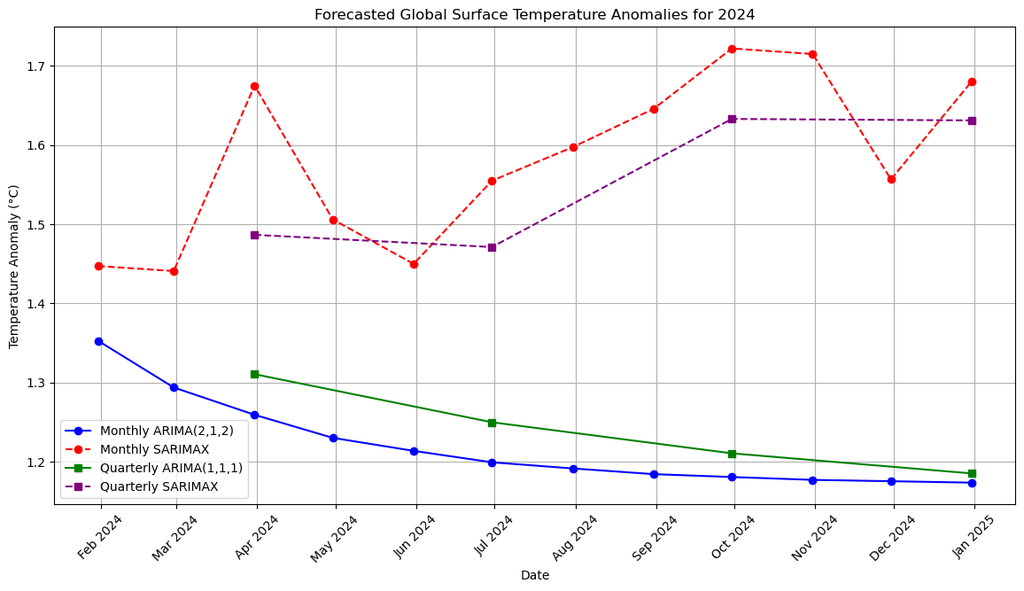

```python
import matplotlib.dates as mdates

# Create date range for monthly and quarterly forecasts of 2024
monthly_forecast_dates = pd.date_range(start='2024-01-01', periods=12, freq='M')
quarterly_forecast_dates = pd.date_range(start='2024-01-01', periods=4, freq='Q')

# Plotting the forecasts
fig, ax = plt.subplots(figsize=(14, 7))

# Plot monthly forecasts
ax.plot(monthly_forecast_dates, monthly_forecast_arima_mean, marker='o', linestyle='-', color='blue', label='Monthly ARIMA(2,1,2)')
ax.plot(monthly_forecast_dates, monthly_forecast_sarimax_mean, marker='o', linestyle='--', color='red', label='Monthly SARIMAX')

# Plot quarterly forecasts
ax.plot(quarterly_forecast_dates, quarterly_forecast_arima_mean, marker='s', linestyle='-', color='green', label='Quarterly ARIMA(1,1,1)')
ax.plot(quarterly_forecast_dates, quarterly_forecast_sarimax_mean, marker='s', linestyle='--', color='purple', label='Quarterly SARIMAX')

# Formatting the plot
ax.set_title('Forecasted Global Surface Temperature Anomalies for 2024')
ax.set_xlabel('Date')
ax.set_ylabel('Temperature Anomaly (°C)')
ax.legend()
ax.grid(True)

# Set x-axis major locator to month and formatter to DateFormatter
ax.xaxis.set_major_locator(mdates.MonthLocator())
ax.xaxis.set_major_formatter(mdates.DateFormatter('%b %Y'))

plt.xticks(rotation=45)
plt.show()
```

The graph outlines the projected global surface temperature anomalies for 2024 using various models. The Monthly ARIMA(2,1,2) model predicts consistent anomalies with a slight decrease towards year-end, while the Monthly SARIMAX model reveals higher peaks in late summer and early autumn, highlighting its ability to capture seasonal variations effectively. The Quarterly ARIMA(1,1,1) shows a continuous decline in anomalies throughout the year. In contrast, the Quarterly SARIMAX indicates stable anomalies in the first half, followed by an increase in the latter half, emphasizing the seasonal impact. These observations suggest that monthly forecasts offer a detailed intra-year variability, with the SARIMAX models predicting higher peaks during warmer months, which correlates with expected seasonal temperature increases. Conversely, quarterly models tend to smooth out monthly fluctuations but underscore broader annual trends. This visualization is crucial for comparing model interpretations and aiding strategic planning and decision-making in climate-sensitive activities.

## 3. UK daily temperature

## A.

```python
import pandas as pd

# Load the data from the files
uk_loc = pd.read_csv('/Users/Rajat/Downloads/Assessment 2 data-20240430/uk_loc.csv')
uk_temp = pd.read_csv('/Users/Rajat/Downloads/Assessment 2 data-20240430/uk_temp.csv')

# Display the first few rows of each dataframe and their structure
uk_loc.head(), uk_loc.info(), uk_temp.head(), uk_temp.info()
```

```
<class 'pandas.core.frame.DataFrame'>
RangeIndex: 27 entries, 0 to 26
Data columns (total 4 columns):
 #   Column             Non-Null Count  Dtype
---  ------             --------------  -----
 0   station_name       27 non-null     object
 1   station_longitude  27 non-null     float64
 2   station_latitude   27 non-null     float64
 3   station_elevation  27 non-null     int64
dtypes: float64(2), int64(1), object(1)
memory usage: 996.0+ bytes
<class 'pandas.core.frame.DataFrame'>
RangeIndex: 365 entries, 0 to 364
Data columns (total 28 columns):
 #   Column        Non-Null Count  Dtype
---  ------        --------------  -----
 0   Date          365 non-null    object
 1   Balmoral      359 non-null    float64
 2   Bedford       365 non-null    float64
 3   Reading       365 non-null    float64
 4   High_Wycombe  285 non-null    float64
 5   Cambridge     343 non-null    float64
 6   Camborne      365 non-null    float64
 7   Keswick       365 non-null    float64
 8   Buxton        365 non-null    float64
 9   Okehampton    360 non-null    float64
 10  Durham        365 non-null    float64
 11  Eastbourne    365 non-null    float64
 12  Leuchars      365 non-null    float64
 13  Cirencester   337 non-null    float64
 14  Kew_Gardens   352 non-null    float64
 15  Rothamsted    365 non-null    float64
 16  Bridlington   365 non-null    float64
 17  Faversham     364 non-null    float64
 18  Blackpool     365 non-null    float64
 19  Scampton      305 non-null    float64
 20  Cromer        365 non-null    float64
 21  Whitby        365 non-null    float64
 22  Wallington    345 non-null    float64
 23  Oxford        365 non-null    float64
 24  Fair_Isle     365 non-null    float64
 25  Yeovilton     365 non-null    float64
 26  Coleshill     365 non-null    float64
 27  Bradford      324 non-null    float64
dtypes: float64(27), object(1)
memory usage: 80.0+ KB
```

```
(   station_name  station_longitude  station_latitude  station_elevation
 0      Balmoral             -3.220            57.037                283
 1       Bedford             -0.465            52.227                 85
 2       Reading             -0.938            51.441                 66
 3  High_Wycombe             -0.807            51.682                204
 4     Cambridge              0.129            52.194                 13,
 None,
          Date  Balmoral  Bedford  Reading  High_Wycombe  Cambridge  Camborne  \
 0  2022-01-01       NaN     14.9     14.6          13.1       15.3      14.0
 1  2022-01-02       NaN     12.3     13.0          12.0       15.2      12.0
 2  2022-01-03       NaN      9.3     10.1           9.0       12.6      11.1
 3  2022-01-04       NaN      8.0      8.6           7.5       10.1       9.0
 4  2022-01-05       NaN      5.6      6.0           5.4        4.4       7.6

    Keswick  Buxton  Okehampton  ...  Blackpool  Scampton  Cromer  Whitby  \
 0     15.9    12.0        11.7  ...       13.5      14.3    14.5    14.1
 1     12.0    12.1        10.1  ...       10.7      12.1    12.2    13.8
 2     10.2     8.5         8.1  ...       10.2       9.8    10.7    11.2
 3      3.5     8.0         6.7  ...        8.2       7.0     8.1     9.8
 4      5.0     2.0         4.4  ...        6.3       5.2     5.4     4.0

    Wallington  Oxford  Fair_Isle  Yeovilton  Coleshill  Bradford
 0        14.2    15.1       10.7       14.1       14.2      14.5
 1        14.2    13.9        9.1       12.7       12.0      11.6
 2        10.4    12.1        8.1       10.7        9.5       9.2
 3         9.0    11.4        5.4        9.4        6.9       7.5
 4         2.1     5.0        5.8        7.3        5.7       4.3

 [5 rows x 28 columns],
 None)
```

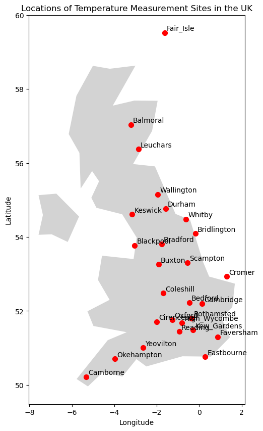

```python
import matplotlib.pyplot as plt
import geopandas as gpd
from shapely.geometry import Point

# Convert location data to GeoDataFrame
gdf = gpd.GeoDataFrame(
    uk_loc,
    geometry=gpd.points_from_xy(uk_loc.station_longitude, uk_loc.station_latitude),
    crs="EPSG:4326"
)

# Create a map of the UK
world = gpd.read_file(gpd.datasets.get_path('naturalearth_lowres'))
uk_map = world[world.name == "United Kingdom"]

# Plotting
fig, ax = plt.subplots(figsize=(10, 10))
uk_map.plot(ax=ax, color='lightgrey')
gdf.plot(ax=ax, marker='o', color='red', markersize=50)
plt.title('Locations of Temperature Measurement Sites in the UK')
plt.xlabel('Longitude')
plt.ylabel('Latitude')

# Annotate each point with the station name
for x, y, label in zip(gdf.geometry.x, gdf.geometry.y, gdf.station_name):
    ax.annotate(label, xy=(x, y), xytext=(3, 3), textcoords="offset points")

plt.show()
```

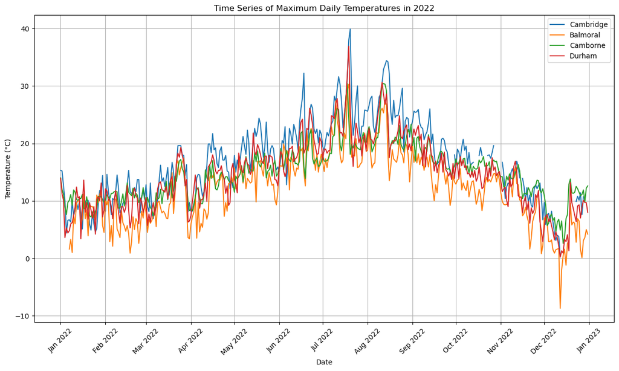

```python
import matplotlib.dates as mdates

# Convert 'Date' to datetime type
uk_temp['Date'] = pd.to_datetime(uk_temp['Date'])

# Selecting a few representative sites for the time series plot
selected_sites = ['Cambridge', 'Balmoral', 'Camborne', 'Durham']

# Plotting
fig, ax = plt.subplots(figsize=(15, 8))
for site in selected_sites:
    ax.plot(uk_temp['Date'], uk_temp[site], label=site)

# Formatting the plot
ax.xaxis.set_major_locator(mdates.MonthLocator())
ax.xaxis.set_major_formatter(mdates.DateFormatter('%b %Y'))
ax.set_title('Time Series of Maximum Daily Temperatures in 2022')
ax.set_xlabel('Date')
ax.set_ylabel('Temperature (°C)')
ax.legend()
plt.grid(True)
plt.xticks(rotation=45)
plt.show()
```

The time series plot reveals distinct seasonal patterns in the temperature data, with temperatures reaching their highest in the summer months of June, July, and August, and dropping to their lowest during the winter months of December, January, and February. Additionally, geographical variations are evident as different locations display varied temperature ranges; for instance, Balmoral, situated in a more northern and elevated region, exhibits lower peak temperatures compared to Cambridge. Despite these geographical differences, there is a consistency across all selected sites in terms of seasonal trends, although the amplitude of temperature changes varies from one site to another.

## B.

```python
# Extracting the coordinates and elevation for all sites
location_data = uk_loc.set_index('station_name')

# Preparing temperature data up to July 23, 2022
temp_data = uk_temp[uk_temp['Date'] < '2022-07-24']

# Merging temperature data with location data for each site to create a comprehensive dataset
temp_data_long = pd.melt(temp_data, id_vars=['Date'], var_name='station_name', value_name='temperature')
merged_data = temp_data_long.merge(location_data, on='station_name')

# Focusing on the latest available temperature for each station as the input for the GP model
latest_temps = merged_data[merged_data['Date'] == '2022-07-23']

# Displaying the data to be used for fitting the GP model
latest_temps.head()
```

|  | Date | station_name | temperature | station_longitude | station_latitude | station_elevation |
| --- | --- | --- | --- | --- | --- | --- |
| 203 | 2022-07-23 | Balmoral | 17.8 | -3.220 | 57.037 | 283 |
| 407 | 2022-07-23 | Bedford | 26.1 | -0.465 | 52.227 | 85 |
| 611 | 2022-07-23 | Reading | 25.5 | -0.938 | 51.441 | 66 |
| 815 | 2022-07-23 | High_Wycombe | 24.1 | -0.807 | 51.682 | 204 |
| 1019 | 2022-07-23 | Cambridge | 23.5 | 0.129 | 52.194 | 13 |

```python
from sklearn.gaussian_process import GaussianProcessRegressor
from sklearn.gaussian_process.kernels import RBF, WhiteKernel, ConstantKernel

# Setting up the Gaussian Process with an RBF kernel
# The RBF kernel uses length_scale parameter which determines the smoothness of the function.
# ConstantKernel adjusts the overall variance of the data
# WhiteKernel is used to account for noise in the data

kernel = ConstantKernel(1.0, (1e-4, 1e1)) * RBF(length_scale=1.0, length_scale_bounds=(1e-2, 1e2)) + WhiteKernel(noise_level=1.0, noise_level_bounds=(1e-3, 1e1))
gp = GaussianProcessRegressor(kernel=kernel, n_restarts_optimizer=10, normalize_y=True)

# Preparing the input features (longitude, latitude, elevation) and the target variable (temperature)
X = latest_temps[['station_longitude', 'station_latitude', 'station_elevation']]
y = latest_temps['temperature']

# Fitting the GP model
gp.fit(X, y)

# Locations for Wallington, Reading, and Whitby on July 24, 2022
prediction_sites = location_data.loc[['Wallington', 'Reading', 'Whitby']]
prediction_input = prediction_sites[['station_longitude', 'station_latitude', 'station_elevation']]

# Making predictions
predictions = gp.predict(prediction_input)
predictions_dict = dict(zip(['Wallington', 'Reading', 'Whitby'], predictions))
predictions_dict
```

```
{'Wallington': 17.204307519723493,
 'Reading': 25.49622511513367,
 'Whitby': 19.80266474865419}
```

```python
from sklearn.model_selection import LeaveOneOut
from sklearn.preprocessing import StandardScaler
from sklearn.metrics import mean_squared_error

# Scaling the features
scaler = StandardScaler()
X_scaled = scaler.fit_transform(X)

# Setup Leave-One-Out Cross Validation (LOOCV)
loo = LeaveOneOut()
loo_mses = []

# Perform LOOCV
for train_index, test_index in loo.split(X_scaled):
    # Split the data
    X_train, X_test = X_scaled[train_index], X_scaled[test_index]
    y_train, y_test = y.iloc[train_index], y.iloc[test_index]

    # Reuse the Gaussian Process model defined earlier
    gp_loocv = GaussianProcessRegressor(kernel=kernel, n_restarts_optimizer=10, normalize_y=True)
    gp_loocv.fit(X_train, y_train)  # Train the model on the train set

    # Predict on the test set
    y_pred = gp_loocv.predict(X_test)

    # Calculate MSE for this fold
    mse = mean_squared_error(y_test, y_pred)
    loo_mses.append(mse)

# Calculate average MSE across all LOOCV folds
average_loo_mse = np.mean(loo_mses)
average_loo_mse
```

```
5.613636402301408
```

## C.

```python
import numpy as np

# Determine the bounds of the grid based on the min and max of longitude and latitude
lon_min, lon_max = uk_loc['station_longitude'].min(), uk_loc['station_longitude'].max()
lat_min, lat_max = uk_loc['station_latitude'].min(), uk_loc['station_latitude'].max()

# Create a grid with 0.05 degree intervals
lon_grid = np.arange(lon_min, lon_max, 0.05)
lat_grid = np.arange(lat_min, lat_max, 0.05)
lon_lat_grid = np.array(np.meshgrid(lon_grid, lat_grid)).T.reshape(-1, 2)

# Prepare grid data for prediction (assuming a constant elevation for simplicity)
# We'll use the mean elevation from the dataset for all grid points
mean_elevation = uk_loc['station_elevation'].mean()
grid_data = np.hstack((lon_lat_grid, np.full((lon_lat_grid.shape[0], 1), mean_elevation)))

# Predict using the fitted Gaussian Process model
grid_predictions, grid_std_devs = gp.predict(grid_data, return_std=True)

# Reshape the predictions and standard deviations for plotting
grid_pred_reshaped = grid_predictions.reshape(len(lat_grid), len(lon_grid))
grid_std_dev_reshaped = grid_std_devs.reshape(len(lat_grid), len(lon_grid))
```

[figure not shown]

```python
import matplotlib.pyplot as plt

# Setting up the plot
fig, axes = plt.subplots(nrows=1, ncols=2, figsize=(15, 7))

# Plot for mean temperature predictions
cmap_mean = plt.get_cmap('coolwarm')
cf1 = axes[0].contourf(lon_grid, lat_grid, grid_pred_reshaped, levels=100, cmap=cmap_mean)
fig.colorbar(cf1, ax=axes[0], orientation='vertical')
axes[0].set_title('Predicted Mean Temperatures (°C)')
axes[0].set_xlabel('Longitude')
axes[0].set_ylabel('Latitude')

# Plot for prediction variances
cmap_variance = plt.get_cmap('viridis')
cf2 = axes[1].contourf(lon_grid, lat_grid, grid_std_dev_reshaped, levels=100, cmap=cmap_variance)
fig.colorbar(cf2, ax=axes[1], orientation='vertical')
axes[1].set_title('Prediction Standard Deviations')
axes[1].set_xlabel('Longitude')
axes[1].set_ylabel('Latitude')

plt.tight_layout()
plt.show()
```

[figure not shown]

```python
# Retrieve coordinates for Wallington, Reading, and Whitby from the location data
specific_sites = ['Wallington', 'Reading', 'Whitby']
specific_locations = location_data.loc[specific_sites]

# Plotting with the specific site markers
fig, axes = plt.subplots(nrows=1, ncols=2, figsize=(15, 7))

# Plot for mean temperature predictions with markers
cf1 = axes[0].contourf(lon_grid, lat_grid, grid_pred_reshaped, levels=100, cmap=cmap_mean)
axes[0].scatter(specific_locations['station_longitude'], specific_locations['station_latitude'], color='black', s=100, label='Specific Sites', zorder=5)
axes[0].legend(loc='upper left')
fig.colorbar(cf1, ax=axes[0], orientation='vertical')
axes[0].set_title('Predicted Mean Temperatures (°C)')
axes[0].set_xlabel('Longitude')
axes[0].set_ylabel('Latitude')

# Plot for prediction variances with markers
cf2 = axes[1].contourf(lon_grid, lat_grid, grid_std_dev_reshaped, levels=100, cmap=cmap_variance)
axes[1].scatter(specific_locations['station_longitude'], specific_locations['station_latitude'], color='black', s=100, label='Specific Sites', zorder=5)
axes[1].legend(loc='upper left')
fig.colorbar(cf2, ax=axes[1], orientation='vertical')
axes[1].set_title('Prediction Standard Deviations')
axes[1].set_xlabel('Longitude')
axes[1].set_ylabel('Latitude')

plt.tight_layout()
plt.show()
```

## (i) Fair Isle on May 1st-5th 2022

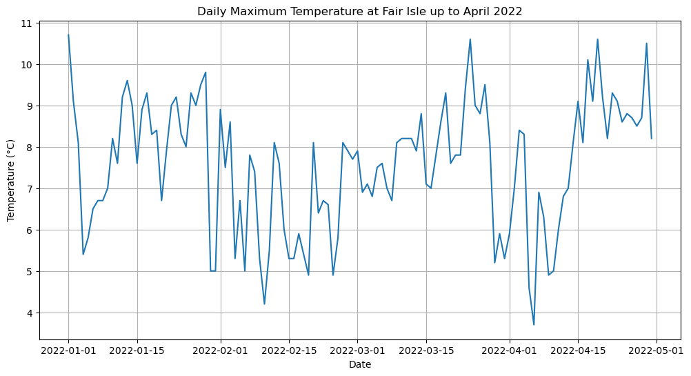

```python
import matplotlib.pyplot as plt

# Extract Fair Isle temperature data and filter up to the end of April 2022
fair_isle_temp = uk_temp[['Date', 'Fair_Isle']]
fair_isle_temp = fair_isle_temp[fair_isle_temp['Date'] <= '2022-04-30']

# Convert Date to datetime
fair_isle_temp['Date'] = pd.to_datetime(fair_isle_temp['Date'])

# Plotting the time series data
plt.figure(figsize=(12, 6))
plt.plot(fair_isle_temp['Date'], fair_isle_temp['Fair_Isle'], label='Max Daily Temperature')
plt.title('Daily Maximum Temperature at Fair Isle up to April 2022')
plt.xlabel('Date')
plt.ylabel('Temperature (°C)')
plt.grid(True)
plt.show()
```

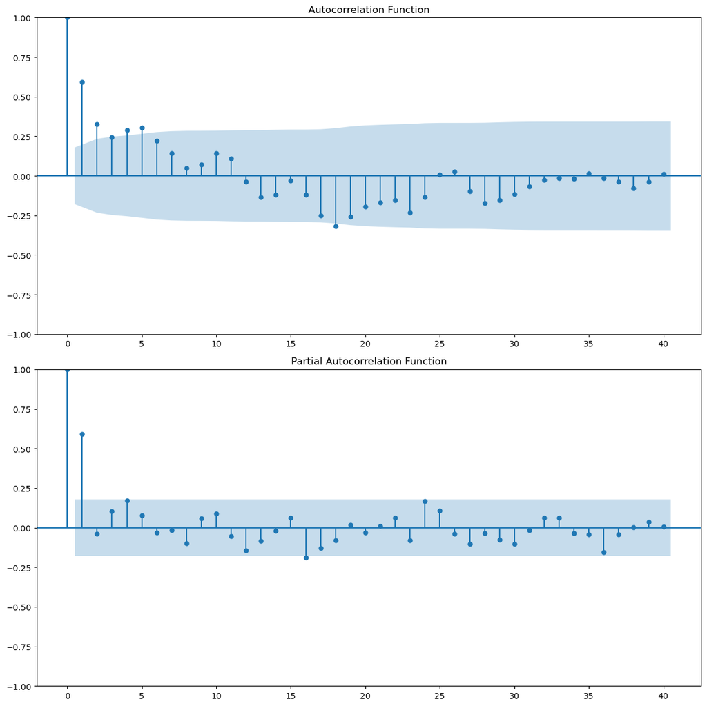

```python
from statsmodels.graphics.tsaplots import plot_acf, plot_pacf

# Plotting ACF and PACF
fig, (ax1, ax2) = plt.subplots(2, 1, figsize=(12, 12))

# Autocorrelation Function (ACF)
plot_acf(fair_isle_temp['Fair_Isle'], lags=40, ax=ax1)
ax1.set_title('Autocorrelation Function')

# Partial Autocorrelation Function (PACF)
plot_pacf(fair_isle_temp['Fair_Isle'], lags=40, ax=ax2, method='ywm')
ax2.set_title('Partial Autocorrelation Function')

plt.tight_layout()
plt.show()
```

```python
from statsmodels.tsa.statespace.sarimax import SARIMAX

# Model fitting: SARIMA(1, 1, 1)(1, 1, 1, 7)
model = SARIMAX(fair_isle_temp['Fair_Isle'],
                order=(1, 1, 1),
                seasonal_order=(1, 1, 1, 7),
                enforce_stationarity=False,
                enforce_invertibility=False)

# Fit the model
fitted_model = model.fit(disp=False)

# Forecasting the first 5 days of May 2022
forecast_dates = pd.date_range(start='2022-05-01', periods=5, freq='D')
forecast = fitted_model.get_forecast(steps=5)
forecast_mean = forecast.predicted_mean
forecast_conf_int = forecast.conf_int()

# Output forecasted means and confidence intervals
forecast_mean, forecast_conf_int
```

```
(120    8.831274
 121    8.959265
 122    8.579359
 123    8.608051
 124    8.803408
 Name: predicted_mean, dtype: float64,
      lower Fair_Isle  upper Fair_Isle
 120         6.237427        11.425121
 121         6.014384        11.904147
 122         5.463574        11.695144
 123         5.365015        11.851087
 124         5.447629        12.159186)
```

The model's forecasts suggest fairly consistent temperatures around 8-9°C for the early days of May, with a confidence interval indicating a range of roughly 5 to 12°C. This spread highlights the inherent uncertainty in weather forecasting, especially when projecting specific daily values.

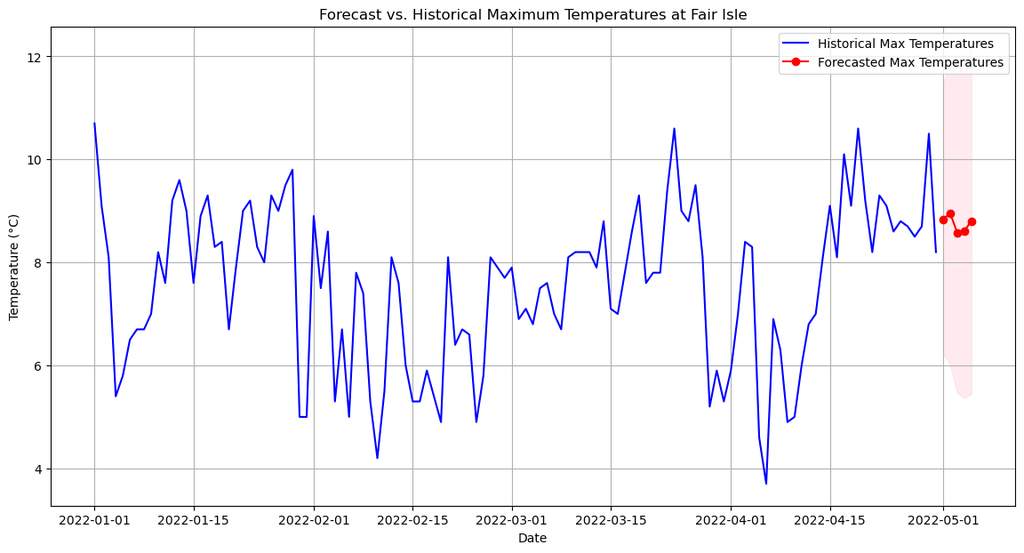

```python
# Ensuring all data types are compatible for plotting
forecast_dates = pd.to_datetime(forecast_dates)  # Confirm forecast_dates are in datetime format

# Convert confidence interval DataFrame to numpy arrays for plotting compatibility
lower_bounds = forecast_conf_int['lower Fair_Isle'].values
upper_bounds = forecast_conf_int['upper Fair_Isle'].values

# Replotting the forecast alongside the historical data with corrected date handling and type conversion
plt.figure(figsize=(14, 7))
plt.plot(fair_isle_temp['Date'], fair_isle_temp['Fair_Isle'], label='Historical Max Temperatures', color='blue')
plt.plot(forecast_dates, forecast_mean.values, label='Forecasted Max Temperatures', color='red', marker='o')

# Plotting the confidence intervals with direct numpy array handling
plt.fill_between(forecast_dates, lower_bounds, upper_bounds, color='pink', alpha=0.3)

plt.title('Forecast vs. Historical Maximum Temperatures at Fair Isle')
plt.xlabel('Date')
plt.ylabel('Temperature (°C)')
plt.legend()
plt.grid(True)
plt.show()
```

## (ii) Bridlington on October 31st-November 4th 2022

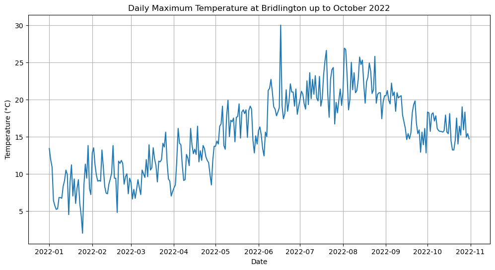

```python
# Extract Bridlington temperature data and filter up to the end of October 2022
bridlington_temp = uk_temp[['Date', 'Bridlington']]
bridlington_temp = bridlington_temp[bridlington_temp['Date'] <= '2022-10-31']

# Convert Date to datetime
bridlington_temp['Date'] = pd.to_datetime(bridlington_temp['Date'])

# Plotting the time series data
plt.figure(figsize=(12, 6))
plt.plot(bridlington_temp['Date'], bridlington_temp['Bridlington'], label='Max Daily Temperature')
plt.title('Daily Maximum Temperature at Bridlington up to October 2022')
plt.xlabel('Date')
plt.ylabel('Temperature (°C)')
plt.grid(True)
plt.show()
```

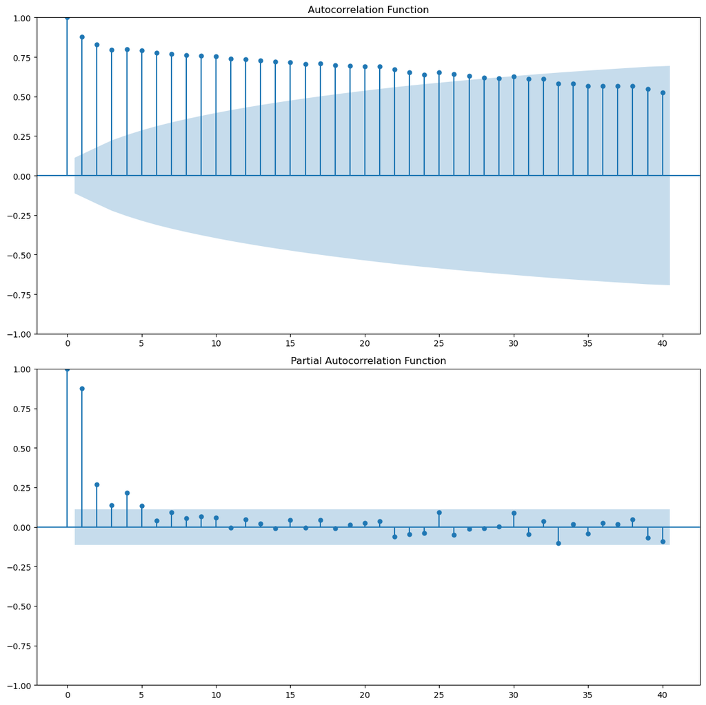

```python
# Plotting ACF and PACF for Bridlington temperature data
fig, (ax1, ax2) = plt.subplots(2, 1, figsize=(12, 12))

# Autocorrelation Function (ACF)
plot_acf(bridlington_temp['Bridlington'], lags=40, ax=ax1)
ax1.set_title('Autocorrelation Function')

# Partial Autocorrelation Function (PACF)
plot_pacf(bridlington_temp['Bridlington'], lags=40, ax=ax2, method='ywm')
ax2.set_title('Partial Autocorrelation Function')

plt.tight_layout()
plt.show()
```

```python
# Fit a SARIMA model: SARIMA(1, 1, 1)(1, 1, 1, 7)
model_bridlington = SARIMAX(bridlington_temp['Bridlington'],
                            order=(1, 1, 1),
                            seasonal_order=(1, 1, 1, 7),
                            enforce_stationarity=False,
                            enforce_invertibility=False)

# Fit the model
fitted_model_bridlington = model_bridlington.fit(disp=False)

# Forecasting from October 31st to November 4th, 2022
forecast_dates_bridlington = pd.date_range(start='2022-10-31', periods=5, freq='D')
forecast_bridlington = fitted_model_bridlington.get_forecast(steps=5)
forecast_mean_bridlington = forecast_bridlington.predicted_mean
forecast_conf_int_bridlington = forecast_bridlington.conf_int()

# Output forecasted means and confidence intervals
forecast_mean_bridlington, forecast_conf_int_bridlington
```

```
(304    15.390120
 305    16.317492
 306    15.651003
 307    16.243122
 308    15.906872
 Name: predicted_mean, dtype: float64,
      lower Bridlington  upper Bridlington
 304          10.880372          19.899869
 305          11.320932          21.314052
 306          10.478218          20.823788
 307          10.963106          21.523137
 308          10.539892          21.273853)
```

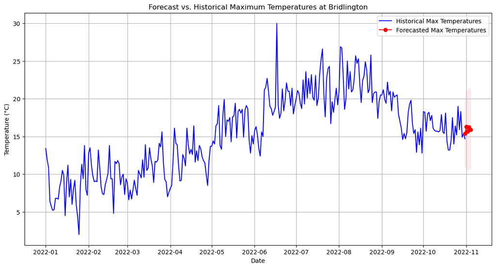

```python
# Convert forecast_dates_bridlington to a pandas datetime index to ensure compatibility
forecast_dates_bridlington = pd.to_datetime(forecast_dates_bridlington)

# Convert confidence interval DataFrame to numpy arrays for plotting compatibility
lower_bounds_bridlington = forecast_conf_int_bridlington['lower Bridlington'].values
upper_bounds_bridlington = forecast_conf_int_bridlington['upper Bridlington'].values

# Replotting the forecast alongside the historical data with corrected date handling and type conversion
plt.figure(figsize=(14, 7))
plt.plot(bridlington_temp['Date'], bridlington_temp['Bridlington'], label='Historical Max Temperatures', color='blue')
plt.plot(forecast_dates_bridlington, forecast_mean_bridlington.values, label='Forecasted Max Temperatures', color='red', marker='o')

# Plotting the confidence intervals with direct numpy array handling
plt.fill_between(forecast_dates_bridlington, lower_bounds_bridlington, upper_bounds_bridlington, color='pink', alpha=0.3)

plt.title('Forecast vs. Historical Maximum Temperatures at Bridlington')
plt.xlabel('Date')
plt.ylabel('Temperature (°C)')
plt.legend()
plt.grid(True)
plt.show()
```